# ML_project

```python
# Import necessary libraries
import pandas as pd  # For data manipulation and analysis
import numpy as np  # For numerical operations and calculations
import matplotlib.pyplot as plt  # For data visualization
import seaborn as sns  # For statistical data visualization
import warnings  # For handling warning messages

# Import machine learning tools
from sklearn.model_selection import train_test_split, cross_val_score  # For splitting data and cross-validation
from sklearn.preprocessing import StandardScaler, LabelEncoder  # For scaling features and encoding categorical data
from sklearn.linear_model import LogisticRegression  # For logistic regression model
from sklearn.metrics import confusion_matrix, accuracy_score, classification_report, f1_score  # For model evaluation metrics
from sklearn.svm import SVC  # For Support Vector Classifier
from sklearn.neighbors import KNeighborsClassifier  # For K-Nearest Neighbors classifier
from sklearn.tree import DecisionTreeClassifier, export_graphviz  # For Decision Tree classifier and exporting tree structure

# Import utilities for visualization in Jupyter Notebooks
from IPython.display import Image  # For displaying images in the notebook
from six import StringIO  # For handling in-memory text streams (used with export_graphviz)

# Suppress warnings
# This prevents unnecessary warning messages from being displayed, keeping the output clean
warnings.filterwarnings('ignore')

# Load data
# Load the dataset into a Pandas DataFrame
df = pd.read_csv('winequality-red.csv')  # Replace 'winequality-red.csv' with the correct path to your dataset
```

```python
# Print data types of each column in the dataset
# This helps identify whether columns are numerical, categorical, or other data types
print(df.dtypes)

# Print the first 5 rows of the dataset
# Provides a quick preview of the data to understand its structure and check for issues
print(df.head())
```

```
fixed acidity                float64
volatile acidity             float64
citric acid                  float64
residual sugar               float64
chlorides                    float64
free sulfur dioxide          float64
total sulfur dioxide         float64
density                      float64
pH                           float64
sulphates                    float64
alcohol                      float64
quality                        int64
alcohol_sulphates            float64
density_ph_ratio             float64
sulphates_sulfur_ratio       float64
log_total_sulfur_dioxide     float64
log_density                  float64
alcohol_squared              float64
sulphates_squared            float64
alcohol_category            category
pH_category                 category
dtype: object
   fixed acidity  volatile acidity  citric acid  residual sugar  chlorides  \
0            7.4              0.70         0.00             1.9      0.076
1            7.8              0.88         0.00             2.6      0.098
2            7.8              0.76         0.04             2.3      0.092
3           11.2              0.28         0.56             1.9      0.075
4            7.4              0.70         0.00             1.9      0.076

   free sulfur dioxide  total sulfur dioxide  density    pH  sulphates  ...  \
0                 11.0                  34.0   0.9978  3.51       0.56  ...
1                 25.0                  67.0   0.9968  3.20       0.68  ...
2                 15.0                  54.0   0.9970  3.26       0.65  ...
3                 17.0                  60.0   0.9980  3.16       0.58  ...
4                 11.0                  34.0   0.9978  3.51       0.56  ...

   quality  alcohol_sulphates  density_ph_ratio  sulphates_sulfur_ratio  \
0        5              5.264          0.284274                0.016471
1        5              6.664          0.311500                0.010149
2        5              6.370          0.305828                0.012037
3        6              5.684          0.315823                0.009667
4        5              5.264          0.284274                0.016471

   log_total_sulfur_dioxide  log_density  alcohol_squared  sulphates_squared  \
0                  3.555348     0.692047            88.36             0.3136
1                  4.219508     0.691546            96.04             0.4624
2                  4.007333     0.691646            96.04             0.4225
3                  4.110874     0.692147            96.04             0.3364
4                  3.555348     0.692047            88.36             0.3136

   alcohol_category pH_category
0               low     neutral
1               low      acidic
2               low     neutral
3               low      acidic
4               low     neutral

[5 rows x 21 columns]
```

[figure not shown]

```python
from sklearn.ensemble import RandomForestClassifier

# Independent variables (X) and dependent variable (y)
X = df.drop('quality', axis=1)
y = df['quality']

# Train a Random Forest model
rf = RandomForestClassifier(random_state=42)
rf.fit(X, y)

# Feature importance
importances = rf.feature_importances_
features = X.columns

# Plot feature importance
plt.figure(figsize=(10, 6))
plt.barh(features, importances, color='skyblue')
plt.title("Feature Importance")
plt.xlabel("Importance Score")
plt.ylabel("Features")
plt.show()
```

In Tree-Based Models (like Random Forest): Feature importance is calculated based on the reduction in impurity (e.g., Gini impurity or entropy) when the feature is used to split data in decision trees. Features that result in larger reductions in impurity are considered more important. In General: High importance: Features that significantly influence the target variable. Low importance: Features that have little to no influence on predictions.

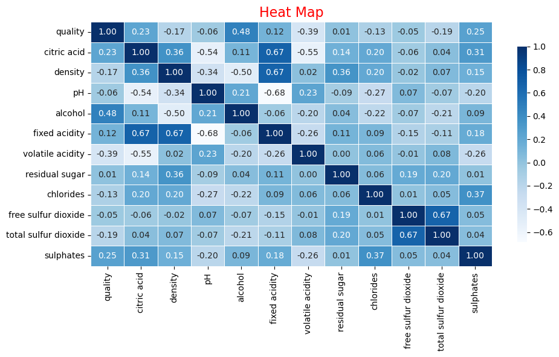

```python
#----------------------------------Data Visualization--------
import pandas as pd
import seaborn as sns
import matplotlib.pyplot as plt

#Heat Map of the relationship between most of the columns in the dataset
correlation_matrix = df[['quality', 'citric acid', 'density', 'pH', 'alcohol', 'fixed acidity', 'volatile acidity',
                             'residual sugar', 'chlorides', 'free sulfur dioxide', 'total sulfur dioxide', 'sulphates']].corr()

plt.figure(figsize=(10, 6))
sns.heatmap(correlation_matrix, annot=True, cmap='Blues', fmt='.2f', linewidths=0.5, cbar_kws={'shrink': 0.8})
plt.title('Heat Map', fontsize=16, color="red")
plt.tight_layout()
plt.show()
```

Heatmap: Feature Relationships This heatmap shows the correlation between key features in the dataset, including quality. Correlation values range from -1 (negative relationship) to 1 (positive relationship), with 0 indicating no linear relationship. It highlights:

Features strongly related to quality. Highly correlated features (multicollinearity). Features with weaker correlations.

[figure not shown]

```python
import matplotlib.pyplot as plt

# Data Visualization: Line Graph of the relationship between wine density and pH
quality_counts = df['pH'].value_counts().sort_index()  # Ensure the index is sorted for a proper line plot

plt.figure(figsize=(10, 6))
plt.plot(quality_counts.index, quality_counts.values, color='purple', marker='o', linestyle='-', linewidth=2)
plt.title('Wine Density vs pH', fontsize=16, color='red')
plt.xlabel('pH', fontsize=14, color='purple')
plt.ylabel('Density', fontsize=14, color='purple')
plt.xticks(fontsize=12, color='purple')
plt.yticks(fontsize=12, color='purple')
plt.grid(alpha=0.3, color='red')
plt.show()
```

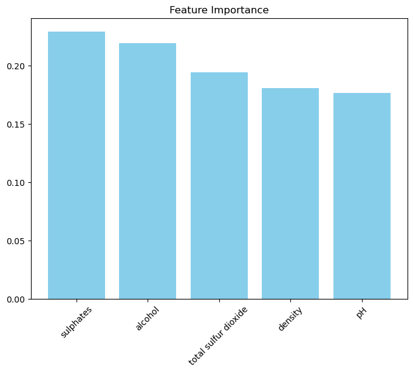

```
Fitting 5 folds for each of 27 candidates, totalling 135 fits
Best Parameters: {'max_depth': 15, 'min_samples_split': 5, 'n_estimators': 200}
Class Weights: {6: 2.527667984189723, 5: 2.321234119782214, 4: 29.74418604651163, 7: 8.146496815286625, 8: 98.38461538461539, 3: 142.11111111111111}
Classification Report:
              precision    recall  f1-score   support

           3       0.00      0.00      0.00         1
           4       0.00      0.00      0.00        10
           5       0.75      0.82      0.78       130
           6       0.67      0.72      0.69       132
           7       0.64      0.55      0.59        42
           8       0.00      0.00      0.00         5

    accuracy                           0.70       320
   macro avg       0.34      0.35      0.34       320
weighted avg       0.67      0.70      0.68       320

Accuracy Score (Random Forest): 0.7
Classification Report (Decision Tree):
              precision    recall  f1-score   support

           3       0.00      0.00      0.00         1
           4       0.00      0.00      0.00        10
           5       0.64      0.79      0.71       130
           6       0.56      0.53      0.55       132
           7       0.38      0.31      0.34        42
           8       0.00      0.00      0.00         5

    accuracy                           0.58       320
   macro avg       0.26      0.27      0.27       320
weighted avg       0.54      0.58      0.56       320

Accuracy Score (Decision Tree): 0.58125
```

```python
# Import necessary libraries
import pandas as pd  # For data manipulation
from sklearn.model_selection import train_test_split, GridSearchCV  # For data splitting and hyperparameter tuning
from sklearn.ensemble import RandomForestClassifier  # Random Forest model
from sklearn.metrics import classification_report, accuracy_score  # For model evaluation
from collections import Counter  # For calculating class distributions
import matplotlib.pyplot as plt  # For plotting feature importance
from sklearn.metrics import classification_report, accuracy_score

# Function to visualize feature importance
def plot_feature_importance(model, feature_names):
    """
    Plots the importance of features based on the trained Random Forest model.
    """
    importances = model.feature_importances_  # Extract feature importance
    indices = importances.argsort()[::-1]    # Sort features by importance
    plt.figure(figsize=(8, 6))               # Set plot size
    plt.bar(range(len(feature_names)), importances[indices], color='skyblue', align='center')  # Bar plot
    plt.xticks(range(len(feature_names)), [feature_names[i] for i in indices], rotation=45)    # Label x-axis
    plt.title("Feature Importance")          # Add title
    plt.show()                               # Show the plot

# Plot the feature importance
plot_feature_importance(rf_model, selected_features)


# Select the most important features based on previous analysis
selected_features = ['alcohol', 'sulphates', 'pH', 'density', 'total sulfur dioxide']

# Define independent variables (X) and dependent variable (y)
X = df[selected_features]
y = df['quality']

# Split the dataset into training and testing sets (80/20 split)
X_train, X_test, y_train, y_test = train_test_split(X, y, test_size=0.2, random_state=42)

# Define the hyperparameter grid for GridSearchCV
param_grid = {
    'n_estimators': [100, 200, 300],        # Number of trees to test
    'max_depth': [10, 15, 20],             # Maximum depth of the trees
    'min_samples_split': [2, 5, 10]        # Minimum samples required to split a node
}

# Perform hyperparameter tuning using GridSearchCV
grid_search = GridSearchCV(
    RandomForestClassifier(random_state=42),  # Random Forest model
    param_grid,                               # Hyperparameter grid
    cv=5,                                     # 5-fold cross-validation
    scoring='accuracy',                       # Use accuracy as the evaluation metric
    verbose=2,                                # Show detailed progress
    n_jobs=-1                                 # Use all available CPU cores
)
grid_search.fit(X_train, y_train)

# Display the best hyperparameters found by GridSearchCV
print("Best Parameters:", grid_search.best_params_)

# Calculate class weights to handle class imbalance
class_counts = Counter(y_train)  # Get the count of each class in the training data
total_samples = len(y_train)     # Total number of samples
class_weights = {cls: total_samples / count for cls, count in class_counts.items()}  # Calculate weights
print("Class Weights:", class_weights)

# Train the Random Forest model with the best parameters and class weights
rf_model = RandomForestClassifier(
    n_estimators=200,           # Use the best number of trees
    max_depth=15,               # Use the best max depth
    random_state=42,            # Ensure reproducibility
    class_weight='balanced'     # Handle class imbalance automatically
)
rf_model.fit(X_train, y_train)

# Make predictions on the test set
y_pred = rf_model.predict(X_test)

# Evaluate the model's performance
print("Classification Report:")
print(classification_report(y_test, y_pred))
print("Accuracy Score (Random Forest):", accuracy_score(y_test, y_pred))

# Train a Decision Tree
clf = DecisionTreeClassifier(max_depth=15, min_samples_split=100, random_state=42)
clf.fit(X_train, y_train)

# Make predictions
y_pred = clf.predict(X_test)

# Evaluate the Decision Tree
print("Classification Report (Decision Tree):")
print(classification_report(y_test, y_pred))  # Includes Precision, Recall, F1-Score
print("Accuracy Score (Decision Tree):", accuracy_score(y_test, y_pred))  # Accuracy
```

The code trains a Decision Tree classifier on the training data (X_train, y_train) and evaluates its performance using metrics like Accuracy, Precision, Recall, and F1-Score. It outputs these metrics through a classification report and prints the overall accuracy score, enabling consistent evaluation and comparison with the Random Forest model.

### **Interpretation of Results**

#### **Random Forest Results**

However, the model struggled with minority classes like `3`, `4`, and `8`, where precision, recall, and F1-scores were all **0.00**. This suggests that the Random Forest failed to effectively learn patterns for these underrepresented classes, despite using class weights to address imbalance. While the macro-average metrics (precision: **0.34**, recall: **0.35**) were low due to these minority class challenges, the weighted averages (precision: **0.67**, recall: **0.70**) were higher, reflecting better performance on majority classes.

#### **Key Insights**

1. The Random Forest outperformed the Decision Tree in terms of accuracy and balanced predictions across majority classes due to its ensemble nature, which reduces overfitting and captures more complex patterns.
2. Both models struggled with minority classes (`3`, `4`, and `8`) because of the class imbalance in the dataset. The metrics for these classes were consistently **0.00**, indicating the models failed to learn patterns for these underrepresented groups.
3. While the Random Forest demonstrated stronger performance overall, further improvements are necessary to handle class imbalance effectively. Techniques like advanced class-weight adjustments could improve predictions for minority classes.
4. Random Forest is better suited for this task, but addressing class imbalance remains crucial for achieving a well-balanced and robust model.

This analysis highlights the strengths and weaknesses of both models, providing a foundation for further optimization and improvement.